# Analyse of a the "Sales of summer clothes in E-commerce Wish" Dataset on Kaggle by Vincent Debande, ESILV A4 DIA 2

## 1.1 Loading the dataset using pandas

```python
import pandas as pd
import matplotlib.pyplot as plt
```

Let's import the data using pandas !

```python
salesAllCol = pd.read_csv("sales.csv",error_bad_lines=False)
```

We now need to check what the dataset looks like to determine what we should do with it.

```python
salesAllCol
```

|  | title | title_orig | price | retail_price | currency_buyer | units_sold | uses_ad_boosts | rating | rating_count | rating_five_count | ... | merchant_rating_count | merchant_rating | merchant_id | merchant_has_profile_picture | merchant_profile_picture | product_url | product_picture | product_id | theme | crawl_month |
| --- | --- | --- | --- | --- | --- | --- | --- | --- | --- | --- | --- | --- | --- | --- | --- | --- | --- | --- | --- | --- | --- |
| 0 | 2020 Summer Vintage Flamingo Print Pajamas Se... | 2020 Summer Vintage Flamingo Print Pajamas Se... | 16.00 | 14 | EUR | 100 | 0 | 3.76 | 54 | 26.0 | ... | 568 | 4.128521 | 595097d6a26f6e070cb878d1 | 0 | NaN | https://www.wish.com/c/5e9ae51d43d6a96e303acdb0 | https://contestimg.wish.com/api/webimage/5e9ae... | 5e9ae51d43d6a96e303acdb0 | summer | 2020-08 |
| 1 | SSHOUSE Summer Casual Sleeveless Soirée Party ... | Women's Casual Summer Sleeveless Sexy Mini Dress | 8.00 | 22 | EUR | 20000 | 1 | 3.45 | 6135 | 2269.0 | ... | 17752 | 3.899673 | 56458aa03a698c35c9050988 | 0 | NaN | https://www.wish.com/c/58940d436a0d3d5da4e95a38 | https://contestimg.wish.com/api/webimage/58940... | 58940d436a0d3d5da4e95a38 | summer | 2020-08 |
| 2 | 2020 Nouvelle Arrivée Femmes Printemps et Été ... | 2020 New Arrival Women Spring and Summer Beach... | 8.00 | 43 | EUR | 100 | 0 | 3.57 | 14 | 5.0 | ... | 295 | 3.989831 | 5d464a1ffdf7bc44ee933c65 | 0 | NaN | https://www.wish.com/c/5ea10e2c617580260d55310a | https://contestimg.wish.com/api/webimage/5ea10... | 5ea10e2c617580260d55310a | summer | 2020-08 |
| 3 | Hot Summer Cool T-shirt pour les femmes Mode T... | Hot Summer Cool T Shirt for Women Fashion Tops... | 8.00 | 8 | EUR | 5000 | 1 | 4.03 | 579 | 295.0 | ... | 23832 | 4.020435 | 58cfdefdacb37b556efdff7c | 0 | NaN | https://www.wish.com/c/5cedf17ad1d44c52c59e4aca | https://contestimg.wish.com/api/webimage/5cedf... | 5cedf17ad1d44c52c59e4aca | summer | 2020-08 |
| 4 | Femmes Shorts d'été à lacets taille élastique ... | Women Summer Shorts Lace Up Elastic Waistband ... | 2.72 | 3 | EUR | 100 | 1 | 3.10 | 20 | 6.0 | ... | 14482 | 4.001588 | 5ab3b592c3911a095ad5dadb | 0 | NaN | https://www.wish.com/c/5ebf5819ebac372b070b0e70 | https://contestimg.wish.com/api/webimage/5ebf5... | 5ebf5819ebac372b070b0e70 | summer | 2020-08 |
| ... | ... | ... | ... | ... | ... | ... | ... | ... | ... | ... | ... | ... | ... | ... | ... | ... | ... | ... | ... | ... | ... |
| 1568 | Nouvelle Mode Femmes Bohême Pissenlit Imprimer... | New Fashion Women Bohemia Dandelion Print Tee ... | 6.00 | 9 | EUR | 10000 | 1 | 4.08 | 1367 | 722.0 | ... | 5316 | 4.224605 | 5b507899ab577736508a0782 | 0 | NaN | https://www.wish.com/c/5d5fadc99febd9356cbc52ee | https://contestimg.wish.com/api/webimage/5d5fa... | 5d5fadc99febd9356cbc52ee | summer | 2020-08 |
| 1569 | 10 couleurs femmes shorts d'été lacent ceintur... | 10 Color Women Summer Shorts Lace Up Elastic W... | 2.00 | 56 | EUR | 100 | 1 | 3.07 | 28 | 11.0 | ... | 4435 | 3.696054 | 54d83b6b6b8a771e478558de | 0 | NaN | https://www.wish.com/c/5eccd22b4497b86fd48f16b4 | https://contestimg.wish.com/api/webimage/5eccd... | 5eccd22b4497b86fd48f16b4 | summer | 2020-08 |
| 1570 | Nouveautés Hommes Siwmwear Beach-Shorts Hommes... | New Men Siwmwear Beach-Shorts Men Summer Quick... | 5.00 | 19 | EUR | 100 | 0 | 3.71 | 59 | 24.0 | ... | 210 | 3.961905 | 5b42da1bf64320209fc8da69 | 0 | NaN | https://www.wish.com/c/5e74be96034d613d42b52dfe | https://contestimg.wish.com/api/webimage/5e74b... | 5e74be96034d613d42b52dfe | summer | 2020-08 |
| 1571 | Mode femmes d'été sans manches robes col en V ... | Fashion Women Summer Sleeveless Dresses V Neck... | 13.00 | 11 | EUR | 100 | 0 | 2.50 | 2 | 0.0 | ... | 31 | 3.774194 | 5d56b32c40defd78043d5af9 | 0 | NaN | https://www.wish.com/c/5eda07ab0e295c2097c36590 | https://contestimg.wish.com/api/webimage/5eda0... | 5eda07ab0e295c2097c36590 | summer | 2020-08 |
| 1572 | Pantalon de yoga pour femmes à la mode Slim Fi... | Fashion Women Yoga Pants Slim Fit Fitness Runn... | 7.00 | 6 | EUR | 100 | 1 | 4.07 | 14 | 8.0 | ... | 7023 | 4.235939 | 5a409cf87b584e7951b2e25f | 0 | NaN | https://www.wish.com/c/5e857321f53c3d2d8f25e7ed | https://contestimg.wish.com/api/webimage/5e857... | 5e857321f53c3d2d8f25e7ed | summer | 2020-08 |

1573 rows × 43 columns

## 1.2 Getting to know our DataSet

We've seen what the dataset looks like. To make some choices and decide how to analyse our data, we'll need some more informations about the columns.

```python
salesAllCol.describe()
```

|  | price | retail_price | units_sold | uses_ad_boosts | rating | rating_count | rating_five_count | rating_four_count | rating_three_count | rating_two_count | ... | badge_fast_shipping | product_variation_inventory | shipping_option_price | shipping_is_express | countries_shipped_to | inventory_total | has_urgency_banner | merchant_rating_count | merchant_rating | merchant_has_profile_picture |
| --- | --- | --- | --- | --- | --- | --- | --- | --- | --- | --- | --- | --- | --- | --- | --- | --- | --- | --- | --- | --- | --- |
| count | 1573.000000 | 1573.000000 | 1573.000000 | 1573.000000 | 1573.000000 | 1573.000000 | 1528.000000 | 1528.000000 | 1528.000000 | 1528.000000 | ... | 1573.000000 | 1573.000000 | 1573.000000 | 1573.000000 | 1573.000000 | 1573.000000 | 473.0 | 1.573000e+03 | 1573.000000 | 1573.000000 |
| mean | 8.325372 | 23.288620 | 4339.005086 | 0.432931 | 3.820896 | 889.659250 | 442.263743 | 179.599476 | 134.549738 | 63.711387 | ... | 0.012715 | 33.081373 | 2.345200 | 0.002543 | 40.456453 | 49.821360 | 1.0 | 2.649583e+04 | 4.032345 | 0.143675 |
| std | 3.932030 | 30.357863 | 9356.539302 | 0.495639 | 0.515374 | 1983.928834 | 980.203270 | 400.516231 | 311.690656 | 151.343933 | ... | 0.112075 | 21.353137 | 1.024371 | 0.050379 | 20.301203 | 2.562799 | 0.0 | 7.847446e+04 | 0.204768 | 0.350871 |
| min | 1.000000 | 1.000000 | 1.000000 | 0.000000 | 1.000000 | 0.000000 | 0.000000 | 0.000000 | 0.000000 | 0.000000 | ... | 0.000000 | 1.000000 | 1.000000 | 0.000000 | 6.000000 | 1.000000 | 1.0 | 0.000000e+00 | 2.333333 | 0.000000 |
| 25% | 5.810000 | 7.000000 | 100.000000 | 0.000000 | 3.550000 | 24.000000 | 12.000000 | 5.000000 | 4.000000 | 2.000000 | ... | 0.000000 | 6.000000 | 2.000000 | 0.000000 | 31.000000 | 50.000000 | 1.0 | 1.987000e+03 | 3.917353 | 0.000000 |
| 50% | 8.000000 | 10.000000 | 1000.000000 | 0.000000 | 3.850000 | 150.000000 | 79.000000 | 31.500000 | 24.000000 | 11.000000 | ... | 0.000000 | 50.000000 | 2.000000 | 0.000000 | 40.000000 | 50.000000 | 1.0 | 7.936000e+03 | 4.040650 | 0.000000 |
| 75% | 11.000000 | 26.000000 | 5000.000000 | 1.000000 | 4.110000 | 855.000000 | 413.500000 | 168.250000 | 129.250000 | 62.000000 | ... | 0.000000 | 50.000000 | 3.000000 | 0.000000 | 43.000000 | 50.000000 | 1.0 | 2.456400e+04 | 4.161797 | 0.000000 |
| max | 49.000000 | 252.000000 | 100000.000000 | 1.000000 | 5.000000 | 20744.000000 | 11548.000000 | 4152.000000 | 3658.000000 | 2003.000000 | ... | 1.000000 | 50.000000 | 12.000000 | 1.000000 | 140.000000 | 50.000000 | 1.0 | 2.174765e+06 | 5.000000 | 1.000000 |

8 rows × 24 columns

```python
salesAllCol.columns
```

```
Index(['title', 'title_orig', 'price', 'retail_price', 'currency_buyer',
       'units_sold', 'uses_ad_boosts', 'rating', 'rating_count',
       'rating_five_count', 'rating_four_count', 'rating_three_count',
       'rating_two_count', 'rating_one_count', 'badges_count',
       'badge_local_product', 'badge_product_quality', 'badge_fast_shipping',
       'tags', 'product_color', 'product_variation_size_id',
       'product_variation_inventory', 'shipping_option_name',
       'shipping_option_price', 'shipping_is_express', 'countries_shipped_to',
       'inventory_total', 'has_urgency_banner', 'urgency_text',
       'origin_country', 'merchant_title', 'merchant_name',
       'merchant_info_subtitle', 'merchant_rating_count', 'merchant_rating',
       'merchant_id', 'merchant_has_profile_picture',
       'merchant_profile_picture', 'product_url', 'product_picture',
       'product_id', 'theme', 'crawl_month'],
      dtype='object')
```

Since there are *a lot* of columns, we'll need to analyse them and keep the ones that we are interested in.

For more information, we can (need) to see Kaggle : https://www.kaggle.com/jmmvutu/summer-products-and-sales-in-ecommerce-wish

## 1.3 Cleaning up the DataSet

Here, we will try and make our dataset more "analysable". We'll need to decide **wich columns to keep and wich columns to get ride of** based on how we want to analyse it.

The main goal of this analysis is to check and see if we find some correlation between the retail price and price (If people get baited by the urge of buying someting with a *"discount"* and basicaly see what can **influences sales of an item**.

```python
salesAllCol[salesAllCol['currency_buyer'] != 'EUR']
```

|  | title | title_orig | price | retail_price | currency_buyer | units_sold | uses_ad_boosts | rating | rating_count | rating_five_count | ... | merchant_rating_count | merchant_rating | merchant_id | merchant_has_profile_picture | merchant_profile_picture | product_url | product_picture | product_id | theme | crawl_month |
| --- | --- | --- | --- | --- | --- | --- | --- | --- | --- | --- | --- | --- | --- | --- | --- | --- | --- | --- | --- | --- | --- |

0 rows × 43 columns

We've checked that all the items are in Euros, the **curency_buyer** column is therefore, meaningless

```python
sales = salesAllCol[['title','price','retail_price','units_sold','rating','uses_ad_boosts','product_color','countries_shipped_to','shipping_option_price','has_urgency_banner','merchant_rating_count','merchant_rating']]
```

It could be interesting to have a column showing the **discount** shown by Wish on an item. *Important :* When an item has a negative discount, there are no discount shown on the website. (For instance: https://www.wish.com/product/2020-summer-vintage-flamingo-print--pajamas-set-casual-loose-t-shirt-top-and-elastic-shorts-women-sleepwear-night-wear-loungewear-sets-5e9ae51d43d6a96e303acdb0?hide_login_modal=true&share=web)

```python
price = (sales['retail_price'] - sales['price'])
totalPrice = (sales['retail_price'] + sales['shipping_option_price'])
```

```python
sales.insert(3,"discount",price)
sales.insert(8,'totalPrice',totalPrice)
```

Now that we have **meaningfull data**, let's analyse our data

```python
sales.columns
```

```
Index(['title', 'price', 'retail_price', 'discount', 'units_sold', 'rating',
       'uses_ad_boosts', 'product_color', 'totalPrice', 'countries_shipped_to',
       'shipping_option_price', 'has_urgency_banner', 'merchant_rating_count',
       'merchant_rating'],
      dtype='object')
```

# 2.1 Let's analyse the clean Dataset

First of all, let's see the top 20 of clothes summer sales on Wish !

```python
sales.sort_values(by='units_sold')[-20:]
```

|  | title | price | retail_price | discount | units_sold | rating | uses_ad_boosts | product_color | totalPrice | countries_shipped_to | shipping_option_price | has_urgency_banner | merchant_rating_count | merchant_rating |
| --- | --- | --- | --- | --- | --- | --- | --- | --- | --- | --- | --- | --- | --- | --- |
| 1188 | Sexy Women Gilet d'été Top Sleeveless Blouse B... | 4.66 | 11 | 6.34 | 50000 | 4.01 | 1 | purple | 12 | 44 | 1 | NaN | 203805 | 4.216477 |
| 84 | 2018 Mode d'été Femmes Débardeurs Débardeurs F... | 7.00 | 6 | -1.00 | 50000 | 4.41 | 1 | green | 8 | 35 | 2 | NaN | 126370 | 4.146957 |
| 1028 | Maillots de bain à rayures pour dames avec dou... | 11.00 | 10 | -1.00 | 50000 | 3.91 | 0 | black | 13 | 31 | 3 | NaN | 17816 | 4.179445 |
| 1466 | Summer Women Sexy White Broderie Sexy White De... | 8.00 | 84 | 76.00 | 50000 | 3.60 | 0 | NaN | 87 | 36 | 3 | 1.0 | 51369 | 3.968269 |
| 40 | Sexy Women Casual T-shirt rayé Long Tops Chemi... | 9.00 | 81 | 72.00 | 50000 | 4.26 | 0 | black | 84 | 40 | 3 | NaN | 59198 | 4.105054 |
| 381 | Sexy Thong Cheeky Bottom Femmes Beachwear Brés... | 5.70 | 58 | 52.30 | 50000 | 3.45 | 0 | black | 59 | 45 | 1 | NaN | 96276 | 4.096234 |
| 875 | Été Femmes Casual Sleeveless T-shirts sans man... | 7.00 | 6 | -1.00 | 50000 | 4.12 | 0 | black | 8 | 18 | 2 | 1.0 | 15538 | 4.156198 |
| 1185 | Cristal paillettes bracelet de cheville ensemb... | 2.00 | 2 | 0.00 | 50000 | 4.01 | 0 | NaN | 3 | 51 | 1 | NaN | 229199 | 4.165079 |
| 790 | Women's Fashion - Chemise sans manches à encol... | 4.00 | 6 | 2.00 | 50000 | 4.00 | 0 | purple | 7 | 30 | 1 | NaN | 13665 | 4.094694 |
| 957 | Sexy Womens manches courtes Party Party Evenin... | 6.00 | 6 | 0.00 | 50000 | 4.20 | 0 | black | 8 | 53 | 2 | NaN | 38264 | 4.227943 |
| 333 | Été Femme Chiffon Chiffon Couleur unie Col en ... | 5.00 | 5 | 0.00 | 50000 | 3.93 | 0 | blue | 6 | 29 | 1 | NaN | 11481 | 4.095288 |
| 952 | Hot Dernières Sexy Bikini Sexy Bikini Femmes M... | 9.00 | 8 | -1.00 | 50000 | 3.83 | 0 | yellow | 11 | 53 | 3 | NaN | 37076 | 4.302082 |
| 510 | Women Fashion Sexy Sleeveless Crop Cops en tri... | 3.00 | 3 | 0.00 | 50000 | 3.81 | 0 | wine red | 4 | 38 | 1 | 1.0 | 151249 | 4.049157 |
| 401 | Femmes dentelle plage boho maxi robe d'été san... | 15.00 | 115 | 100.00 | 50000 | 3.94 | 1 | white | 119 | 38 | 4 | NaN | 165915 | 4.256077 |
| 92 | Femmes Camisole extensible Spaghetti Strap Lon... | 5.77 | 48 | 42.23 | 100000 | 4.10 | 0 | black | 50 | 46 | 2 | NaN | 330405 | 4.067348 |
| 214 | Nouveau Aeeival Femmes Vêtements À Manches Lon... | 8.00 | 7 | -1.00 | 100000 | 3.76 | 1 | light green | 9 | 38 | 2 | NaN | 108048 | 4.052504 |
| 1018 | Femmes dentelle manches courtes hauts hauts ch... | 7.00 | 22 | 15.00 | 100000 | 3.82 | 1 | NaN | 24 | 46 | 2 | NaN | 320031 | 4.218866 |
| 251 | T-shirt à manches courtes en mousseline de soi... | 5.00 | 33 | 28.00 | 100000 | 3.98 | 0 | orange | 34 | 41 | 1 | NaN | 366898 | 4.036081 |
| 17 | 2018 New Fashion Women's Tops Sexy Strappy Sle... | 5.00 | 25 | 20.00 | 100000 | 3.83 | 1 | white | 26 | 41 | 1 | 1.0 | 139223 | 3.933581 |
| 1168 | Nouvelle arrivée femmes été sexy robe de soiré... | 5.67 | 19 | 13.33 | 100000 | 3.53 | 0 | grey | 20 | 37 | 1 | 1.0 | 19248 | 3.889131 |

## 2.2 Aggregates questions

### 2.2.1 Question 1

It could be interesting to see how many items are rated over **4 out of 5**

```python
sales[sales.rating >= 4].count()
```

```
title                    597
price                    597
retail_price             597
discount                 597
units_sold               597
rating                   597
uses_ad_boosts           597
product_color            575
totalPrice               597
countries_shipped_to     597
shipping_option_price    597
has_urgency_banner       178
merchant_rating_count    597
merchant_rating          597
dtype: int64
```

Well, out of 1573 items, 597 *(about 40%)* are rated with at least a 4/5 wich means the community liked it a lot.

### 2.2.2 Question 2

Now, we've seen *round numbers* for units_sold column, wouldn't be interesting to investigate ?

```python
sales.groupby("units_sold").count()
```

| units_sold | title | price | retail_price | discount | rating | uses_ad_boosts | product_color | totalPrice | countries_shipped_to | shipping_option_price | has_urgency_banner | merchant_rating_count | merchant_rating |
| --- | --- | --- | --- | --- | --- | --- | --- | --- | --- | --- | --- | --- | --- |
| 1 | 3 | 3 | 3 | 3 | 3 | 3 | 3 | 3 | 3 | 3 | 0 | 3 | 3 |
| 2 | 2 | 2 | 2 | 2 | 2 | 2 | 1 | 2 | 2 | 2 | 0 | 2 | 2 |
| 3 | 2 | 2 | 2 | 2 | 2 | 2 | 2 | 2 | 2 | 2 | 0 | 2 | 2 |
| 6 | 1 | 1 | 1 | 1 | 1 | 1 | 1 | 1 | 1 | 1 | 0 | 1 | 1 |
| 7 | 2 | 2 | 2 | 2 | 2 | 2 | 2 | 2 | 2 | 2 | 0 | 2 | 2 |
| 8 | 4 | 4 | 4 | 4 | 4 | 4 | 4 | 4 | 4 | 4 | 1 | 4 | 4 |
| 10 | 49 | 49 | 49 | 49 | 49 | 49 | 47 | 49 | 49 | 49 | 15 | 49 | 49 |
| 50 | 76 | 76 | 76 | 76 | 76 | 76 | 75 | 76 | 76 | 76 | 28 | 76 | 76 |
| 100 | 509 | 509 | 509 | 509 | 509 | 509 | 496 | 509 | 509 | 509 | 156 | 509 | 509 |
| 1000 | 405 | 405 | 405 | 405 | 405 | 405 | 394 | 405 | 405 | 405 | 124 | 405 | 405 |
| 5000 | 217 | 217 | 217 | 217 | 217 | 217 | 214 | 217 | 217 | 217 | 64 | 217 | 217 |
| 10000 | 177 | 177 | 177 | 177 | 177 | 177 | 175 | 177 | 177 | 177 | 52 | 177 | 177 |
| 20000 | 103 | 103 | 103 | 103 | 103 | 103 | 98 | 103 | 103 | 103 | 28 | 103 | 103 |
| 50000 | 17 | 17 | 17 | 17 | 17 | 17 | 15 | 17 | 17 | 17 | 3 | 17 | 17 |
| 100000 | 6 | 6 | 6 | 6 | 6 | 6 | 5 | 6 | 6 | 6 | 2 | 6 | 6 |

How about that ? We can guess that they rounded the numbers up. Let's check it out !

```python
sales.groupby("units_sold").mean()
```

| units_sold | price | retail_price | discount | rating | uses_ad_boosts | totalPrice | countries_shipped_to | shipping_option_price | has_urgency_banner | merchant_rating_count | merchant_rating |
| --- | --- | --- | --- | --- | --- | --- | --- | --- | --- | --- | --- |
| 1 | 9.240000 | 17.666667 | 8.426667 | 5.000000 | 0.000000 | 20.000000 | 31.000000 | 2.333333 | NaN | 964.000000 | 3.853679 |
| 2 | 13.500000 | 13.000000 | -0.500000 | 3.500000 | 0.000000 | 17.000000 | 25.500000 | 4.000000 | NaN | 11000.000000 | 4.151046 |
| 3 | 9.905000 | 22.500000 | 12.595000 | 5.000000 | 0.000000 | 25.000000 | 41.500000 | 2.500000 | NaN | 7764.000000 | 4.121399 |
| 6 | 6.000000 | 17.000000 | 11.000000 | 5.000000 | 0.000000 | 19.000000 | 43.000000 | 2.000000 | NaN | 65189.000000 | 4.049640 |
| 7 | 8.000000 | 32.000000 | 24.000000 | 5.000000 | 0.000000 | 35.000000 | 50.500000 | 3.000000 | NaN | 57198.000000 | 4.150543 |
| 8 | 7.750000 | 58.750000 | 51.000000 | 5.000000 | 0.000000 | 61.500000 | 43.000000 | 2.750000 | 1.0 | 13775.750000 | 3.924989 |
| 10 | 8.443878 | 33.000000 | 24.556122 | 4.182653 | 0.244898 | 35.408163 | 40.510204 | 2.408163 | 1.0 | 7867.183673 | 3.884710 |
| 50 | 7.853553 | 19.657895 | 11.804342 | 3.878421 | 0.342105 | 21.960526 | 40.078947 | 2.302632 | 1.0 | 8758.881579 | 3.960837 |
| 100 | 8.082083 | 22.701375 | 14.619293 | 3.725246 | 0.479371 | 24.952849 | 40.404715 | 2.251473 | 1.0 | 14746.937132 | 3.998240 |
| 1000 | 8.586667 | 24.777778 | 16.191111 | 3.804765 | 0.461728 | 27.185185 | 41.535802 | 2.407407 | 1.0 | 18053.303704 | 4.041770 |
| 5000 | 8.483088 | 20.433180 | 11.950092 | 3.820092 | 0.382488 | 22.838710 | 39.967742 | 2.405530 | 1.0 | 31417.612903 | 4.067306 |
| 10000 | 8.313559 | 20.655367 | 12.341808 | 3.896836 | 0.412429 | 23.039548 | 40.124294 | 2.384181 | 1.0 | 49582.553672 | 4.086179 |
| 20000 | 8.729612 | 26.932039 | 18.202427 | 3.867961 | 0.475728 | 29.339806 | 38.466019 | 2.407767 | 1.0 | 63210.679612 | 4.108646 |
| 50000 | 6.962353 | 27.882353 | 20.920000 | 3.903529 | 0.235294 | 29.941176 | 40.588235 | 2.058824 | 1.0 | 126212.000000 | 4.122323 |
| 100000 | 6.073333 | 25.666667 | 19.593333 | 3.836667 | 0.500000 | 27.166667 | 41.500000 | 1.500000 | 1.0 | 213975.500000 | 4.032919 |

Those tables will be super useful do draw some graphs ! We'll come back later

### 2.2.3 Question 3

We've seen that a few items has been sold *a lot*. Since there is not much data on these, let's focus the **many items that has an average sales**. How many have a good rating ? Let's figure it out !

```python
sales[sales.units_sold == 10000].rating.mean()
```

```
3.8968361581920905
```

The mean of the rating seems pretty high, let's get some more information

```python
sales[sales.units_sold == 10000].rating.describe()
```

```
count    177.000000
mean       3.896836
std        0.290220
min        3.010000
25%        3.710000
50%        3.930000
75%        4.130000
max        4.470000
Name: rating, dtype: float64
```

We can finaly check how many items have at least a 4/5 rating

```python
sales[(sales.units_sold == 10000) & (sales.rating >= 4)].describe()
```

|  | price | retail_price | discount | units_sold | rating | uses_ad_boosts | totalPrice | countries_shipped_to | shipping_option_price | has_urgency_banner | merchant_rating_count | merchant_rating |
| --- | --- | --- | --- | --- | --- | --- | --- | --- | --- | --- | --- | --- |
| count | 71.000000 | 71.000000 | 71.000000 | 71.0 | 71.000000 | 71.000000 | 71.000000 | 71.000000 | 71.000000 | 26.0 | 7.100000e+01 | 71.000000 |
| mean | 8.386197 | 27.140845 | 18.754648 | 10000.0 | 4.170282 | 0.436620 | 29.563380 | 43.197183 | 2.422535 | 1.0 | 6.059466e+04 | 4.155361 |
| std | 3.523195 | 35.507865 | 34.755110 | 0.0 | 0.112871 | 0.499497 | 35.816091 | 23.699078 | 1.077855 | 0.0 | 2.577414e+05 | 0.132065 |
| min | 1.770000 | 2.000000 | -2.000000 | 10000.0 | 4.000000 | 0.000000 | 3.000000 | 17.000000 | 1.000000 | 1.0 | 7.830000e+02 | 3.849194 |
| 25% | 6.000000 | 7.000000 | -1.000000 | 10000.0 | 4.075000 | 0.000000 | 9.000000 | 34.000000 | 2.000000 | 1.0 | 5.816000e+03 | 4.073866 |
| 50% | 8.000000 | 10.000000 | 0.230000 | 10000.0 | 4.150000 | 0.000000 | 13.000000 | 40.000000 | 2.000000 | 1.0 | 1.450200e+04 | 4.167805 |
| 75% | 11.000000 | 28.000000 | 23.000000 | 10000.0 | 4.255000 | 1.000000 | 29.500000 | 43.000000 | 3.000000 | 1.0 | 3.399300e+04 | 4.247121 |
| max | 18.000000 | 140.000000 | 132.000000 | 10000.0 | 4.470000 | 1.000000 | 143.000000 | 138.000000 | 7.000000 | 1.0 | 2.174765e+06 | 4.395747 |

## 2.3 Plot questions

Now that we've seen a lot of information, let's try and analyse the data using **graphs**.

### 2.3.1 Does the quality have a influence over the price ?

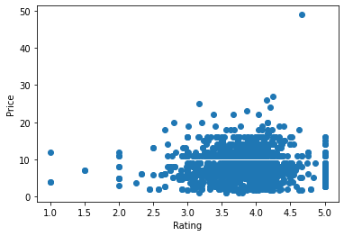

```python
plt.scatter(sales.rating,sales.price)

plt.xlabel('Rating')
plt.ylabel('Price')
```

Hum, looks like there is no correlation *at all* !

Let's try to group by the rating and show the mean of the price

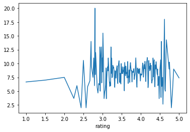

```python
sales.groupby('rating')['price'].mean().plot()
```

Again, we can see that the quality of an item does not influence its price.

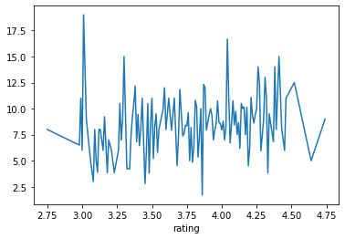

```python
sales[(sales.units_sold == 1000)].groupby('rating')['price'].mean().plot()
```

### 2.3.2 What does influence the number of sales ?

We could think that the greatest the discount is, better the sales are. Let's check it out !

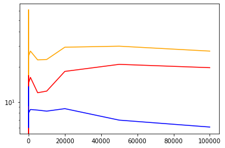

```python
plt.plot(sales.groupby('units_sold')['discount'].mean(),color='red',label='discount')

plt.plot(sales.groupby('units_sold')['price'].mean(),color='blue',label='price')

plt.plot(sales.groupby('units_sold')['totalPrice'].mean(),color='orange',label='totalPrice')

plt.yscale("log")
```

I've used a **logarithmic scale** in order to have a better view on the variations.

It seems that the *price* have some influence over the *units sold*.

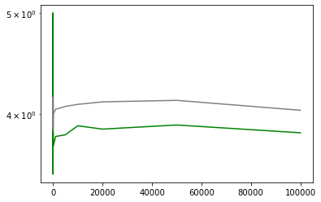

```python
plt.plot(sales.groupby('units_sold')['rating'].mean(),color='green',label='rating')

plt.plot(sales.groupby('units_sold')['merchant_rating'].mean(),color='grey',label='merchant_rating')

plt.yscale("log")
```

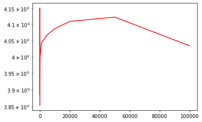

```python
plt.plot(sales.groupby('units_sold')['merchant_rating'].mean(),color='red')

plt.yscale("log")
```